# Bellabeat Case Study

Kevin Proudler

2023-12-29

## About

Urška Sršen and Sando Mur founded Bellabeat, a high-tech company that manufactures health-focused smart products. Collecting data on activity, sleep, stress, and reproductive health has allowed Bellabeat to empower women with knowledge about their health and habits. Sršen knows that an analysis of Bellabeat’s available consumer data would reveal more growth opportunities. She has asked the marketing analytics team to focus on a Bellabeat product and analyze smart device usage data to gain insight into how people are already using their smart devices. Then, using this information, she would like high-level recommendations for how these trends can inform Bellabeat’s marketing strategy.

## Ask

Sršen asks you to analyze smart device usage data in order to gain insight into how consumer use non-Bellabeat smart devices.

1. What are some trends in smart device usage?
2. How could these trends apply to Bellabeat customers?
3. How could these trends help influence Bellabeat’s marketing strategy?

To provide an answer to these questions, I will be taking a look at [FitBit Fitness Tracker Data](https://www.kaggle.com/arashnic/fitbit). This is a Kaggle data set that contains personal fitness tracker data, including physical activity, heart rate, weight, and sleep. Our analysis will be geared towards one, or a selection of the following Bellabeat products:

-**Bellabeat app**: Provides users with health data related to their activity, sleep, stress, menstrual cycle, and mindfulness habits. This data can help users better understand their habits and make healthy decisions.

-**Leaf**: Wellness tracker that can be worn as a bracelet, necklace, or clip. Tracks activity, sleep, and stress.

-**Time**: A smartwatch that tracks user activity, sleep, and stress.

-**Spring**: A water bottle that tracks daily water intake.

-**Bellabeat Membership**: Subscription-based membership program for users that gives guidance on nutrition, activity, sleep, health and beauty, and mindfulness.

## Data Source

### Issues

-User gender is not revealed in the data. As Bellabeat is a company focusing on creating health and wellness products for women, this may be an issue. Other personal data of the users that aren’t included are their age, ethnicity, or location. This may be an issue when it comes to the specificity of the analysis for Bellabeat’s target market.

## Data Cleaning

All data sets from [FitBit Fitness Tracker Data](https://www.kaggle.com/arashnic/fitbit) have been downloaded and will be analyzed.

In preparation for the analysis, the following packages will be loaded.

```r
library(ggplot2)
library(tidyverse)
library(dplyr)
library(tidyr)
library(lubridate)
library(data.table)
library(janitor)
library(skimr)
```

Loading all CSV files with health data into a list.

```r
file_list <- list.files(path = "Fitabase Data 4.12.16-5.12.16/", full.names = TRUE)
datasets <- lapply(file_list, fread)
names(datasets) <- gsub('.{11}$', '', basename(file_list))
```

Each file has been appended with “_merged.csv”, which has been removed to ease referencing.

To begin analyzing the data, I need to be able to understand what I’m working with. I will be creating a summary of the data files showing the number of columns and rows, how many N/A fields, distinct IDs, and duplicates are found in each.

```r
ds_summary <- data.frame(
  sapply(datasets, nrow),
  sapply(datasets, ncol),
  sapply(datasets, FUN = function(x) {sum(is.na(x))}),
  sapply(datasets, FUN = function(x) {n_distinct(x[[1]])}),
  sapply(datasets, FUN = function(x) {sum(duplicated(x))})
)
names(ds_summary) <- c("# Rows", "# Columns", "# NA", "# Distinct ID", "# Duplicated")

ds_summary
```

```
##                          # Rows # Columns # NA # Distinct ID # Duplicated
## dailyActivity               940        15    0            33            0
## dailyCalories               940         3    0            33            0
## dailyIntensities            940        10    0            33            0
## dailySteps                  940         3    0            33            0
## heartrate_seconds       2483658         3    0            14            0
## hourlyCalories            22099         3    0            33            0
## hourlyIntensities         22099         4    0            33            0
## hourlySteps               22099         3    0            33            0
## minuteCaloriesNarrow    1325580         3    0            33            0
## minuteCaloriesWide        21645        62    0            33            0
## minuteIntensitiesNarrow 1325580         3    0            33            0
## minuteIntensitiesWide     21645        62    0            33            0
## minuteMETsNarrow        1325580         3    0            33            0
## minuteSleep              188521         4    0            24          543
## minuteStepsNarrow       1325580         3    0            33            0
## minuteStepsWide           21645        62    0            33            0
## sleepDay                    413         5    0            24            3
## weightLogInfo                67         8   65             8            0
```

-The summary indicates that most data sets have 33 Distinct IDs, other than *minuteSleep*, *heartrate_seconds*, *sleepDay*, and *weightLogInfo*.

-There are also 2 data sets that have duplicated data: *minuteSleep*, and *sleepDay*.

-weightLogInfo is showing 65 NAs in the dataset.

```r
sapply(datasets$weightLogInfo, FUN = function(x) {sum(is.na(x))})
```

```
##             Id           Date       WeightKg   WeightPounds            Fat
##              0              0              0              0             65
##            BMI IsManualReport          LogId
##              0              0              0
```

-Upon further inspection, the NAs were all located within the column *Fat*. As there are a total of 67 rows in this data set, this column will not be useful with that much missing data.

#### Next Steps

-Remove duplicates from *minuteSleep* and *sleepDay*

-Drop the *Fat* column from *weightLogInfo*

```r
datasets$weightLogInfo <- select(datasets$weightLogInfo, -Fat)
datasets$sleepDay <- unique(datasets$sleepDay)
datasets$minuteSleep <- unique(datasets$minuteSleep)

ds_summary <- data.frame(
  sapply(datasets, nrow),
  sapply(datasets, ncol),
  sapply(datasets, FUN = function(x) {sum(is.na(x))}),
  sapply(datasets, FUN = function(x) {n_distinct(x[[1]])}),
  sapply(datasets, FUN = function(x) {sum(duplicated(x))})
)
names(ds_summary) <- c("# Rows", "# Columns", "# NA", "# Distinct ID", "# Duplicated")
ds_summary
```

```
##                          # Rows # Columns # NA # Distinct ID # Duplicated
## dailyActivity               940        15    0            33            0
## dailyCalories               940         3    0            33            0
## dailyIntensities            940        10    0            33            0
## dailySteps                  940         3    0            33            0
## heartrate_seconds       2483658         3    0            14            0
## hourlyCalories            22099         3    0            33            0
## hourlyIntensities         22099         4    0            33            0
## hourlySteps               22099         3    0            33            0
## minuteCaloriesNarrow    1325580         3    0            33            0
## minuteCaloriesWide        21645        62    0            33            0
## minuteIntensitiesNarrow 1325580         3    0            33            0
## minuteIntensitiesWide     21645        62    0            33            0
## minuteMETsNarrow        1325580         3    0            33            0
## minuteSleep              187978         4    0            24            0
## minuteStepsNarrow       1325580         3    0            33            0
## minuteStepsWide           21645        62    0            33            0
## sleepDay                    410         5    0            24            0
## weightLogInfo                67         7    0             8            0
```

## Analyzing the Data

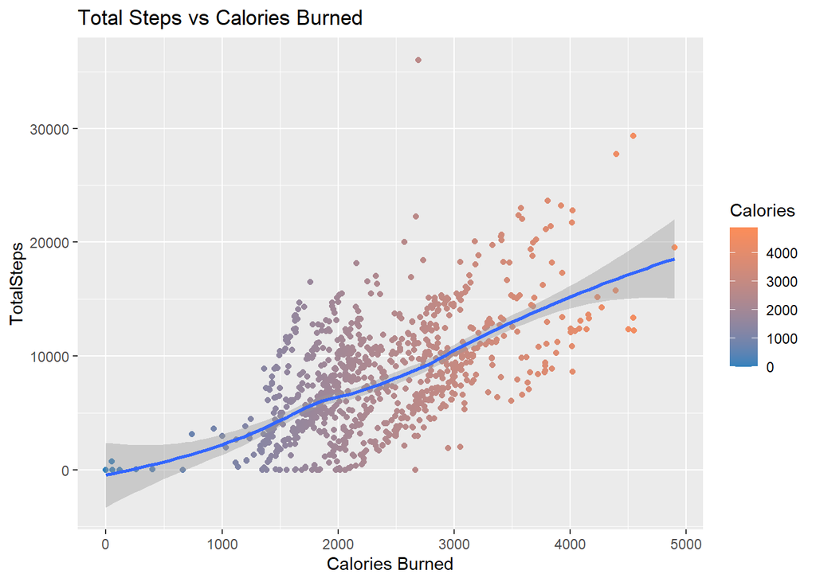

```r
ggplot(datasets$dailyActivity, mapping = aes(x = Calories, y = TotalSteps, color = Calories)) +
  geom_point() +
  geom_smooth(method = "loess") +
  labs(title = "Total Steps vs Calories Burned", x = "Calories Burned") +
  scale_color_gradient(low = "#3182bd", high = "#fc8d59")
```

We can see a positive correlation between the calories burned and the total steps taken: the more steps you take, the greater the expected calorie burn.

Let’s take a deeper look into the daily activity and its summary statistics.

```r
datasets$dailyActivity %>%
  select(TotalSteps,
         TotalDistance,
         VeryActiveMinutes,
         FairlyActiveMinutes,
         LightlyActiveMinutes,
         SedentaryMinutes) %>%
  summary()
```

```
##    TotalSteps    TotalDistance    VeryActiveMinutes FairlyActiveMinutes
##  Min.   :    0   Min.   : 0.000   Min.   :  0.00    Min.   :  0.00
##  1st Qu.: 3790   1st Qu.: 2.620   1st Qu.:  0.00    1st Qu.:  0.00
##  Median : 7406   Median : 5.245   Median :  4.00    Median :  6.00
##  Mean   : 7638   Mean   : 5.490   Mean   : 21.16    Mean   : 13.56
##  3rd Qu.:10727   3rd Qu.: 7.713   3rd Qu.: 32.00    3rd Qu.: 19.00
##  Max.   :36019   Max.   :28.030   Max.   :210.00    Max.   :143.00
##  LightlyActiveMinutes SedentaryMinutes
##  Min.   :  0.0        Min.   :   0.0
##  1st Qu.:127.0        1st Qu.: 729.8
##  Median :199.0        Median :1057.5
##  Mean   :192.8        Mean   : 991.2
##  3rd Qu.:264.0        3rd Qu.:1229.5
##  Max.   :518.0        Max.   :1440.0
```

This summary provides some great insight into the activity of the users:

-On average, the users logged 7,638 steps per day. This number is below the recommended 10,000 [CDC](https://www.cdc.gov/diabetes/prevention/pdf/postcurriculum_session8.pdf)

-On average, a user will log 991.2 Sedentary Minutes per day.

-On average, Sedentary Minutes greatly outnumbered the aggregate of Very Active, Fairly Active, and Lightly Active Minutes.

## Recommendation

1. What are some trends in smart device usage?
- Users spend the majority of their time in a sedentary state
- Users on average do not hit the CDC-recommended daily steps or activity metrics
2. How could the above trends be used to inform Bellabeats decisions? Bellabeats, being a health and wellness company, will benefit from the improvement in their users’ lifestyles. Bellabeats can use these trends to gather insights into how users use their products and can figure out ways to encourage their users to increase their activity.
3. How could these trends help influence Bellabeat marketing strategy? Bellabeats could develop strategies to increase their users’ activity, for example, by issuing notifications at certain points during the day if the user is below the benchmark activity level, by issuing a notification to the user that their weekly average activity is below their goal or other similar tactics. Bellabeats would be able to use any positive outcomes from these initiatives to market their products as a tool that will help users get closer to achieving their health and wellness goals.